# Discussion-10

waheeb Algabri

### chapter 12,EX 1

Using the Binomial Theorem, show that

$\frac{1}{\sqrt{1-4x}} = \sum_{m=0}^{\infty} \binom{2m}{m} x^m$

What is the interval of convergence of this power series?

##### The Solution

To use the Binomial Theorem, we have:

$$(1+x)^{\frac{1}{2}} =
\sum_{m=0}^{\infty} \binom{\frac{1}{2}}{m} (2mx)^m$$

Where $\binom{\frac{1}{2}}{m} = \frac{\frac{1}{2}(\frac{1}{2}-1)(\frac{1}{2}-2)...(\frac{1}{2}-m+1)}{m!}$ is the binomial coefficient.

Now, $\binom{\frac{1}{2}}{m} = \frac{\frac{1}{2}(\frac{-1}{2})(\frac{-3}{2})...(\frac{-2m+1}{2})}{m!} = \frac{(-1)^m}{2^m} \cdot \frac{1 \cdot 3 \cdot 5 \cdot ... \cdot (2m-1)}{m!}$

And $\frac{1 \cdot 3 \cdot 5 \cdot ... \cdot (2m-1)}{m!} = \frac{(2m)!}{m! \cdot 2^m \cdot m!} = \frac{(2m)!}{(m!)^2 \cdot 2^m}$

So, $\binom{\frac{1}{2}}{m} = \frac{(-1)^m}{2^m} \cdot \frac{(2m)!}{(m!)^2 \cdot 2^{2m}}$

Now, plug this back into the power series:

$$(1+x)^{\frac{1}{2}} =
\sum_{m=0}^{\infty} \frac{(-1)^m \cdot (2m)!}{(m!)^2 \cdot 2^{2m}} \cdot
(2mx)^m$$

Simplifying this gives:

$$(1+x)^{\frac{1}{2}} =
\sum_{m=0}^{\infty} \frac{(-1)^m \cdot (2m)!}{(m!)^2 \cdot 2^{2m}} \cdot
(2mx)^m$$

Now, for the interval of convergence, we can use the ratio test:

$$\lim_{m \to \infty} \left|
\frac{a_{m+1}}{a_m} \right| < 1$$

Where $a_m = \frac{(-1)^m \cdot (2m)!}{(m!)^2 \cdot 2^{2m}} \cdot (2mx)^m$

$$\lim_{m \to \infty} \left|
\frac{(-1)^{m+1} \cdot (2m+2)! \cdot (2mx)^{m+1} \cdot (m!)^2 \cdot
2^{2m}}{(-1)^m \cdot (2m)! \cdot ((m+1)!)^2 \cdot 2^{2(m+1)} \cdot
(2mx)^m} \right| < 1$$

$$\lim_{m \to \infty} \left|
\frac{(2m+2)! \cdot (2mx)^{m+1} \cdot (m!)^2 \cdot 2^{2m}}{(2m)! \cdot
((m+1)!)^2 \cdot 2^{2(m+1)} \cdot (2mx)^m} \right| < 1$$

$$\lim_{m \to \infty} \left|
\frac{(2m+1)(2m+2)(2x)}{(m+1)^2 \cdot 2^2} \right| < 1$$

$$\lim_{m \to \infty} \left|
\frac{(2m+1)(2x)}{(m+1)^2 \cdot 4} \right| < 1$$

$$\lim_{m \to \infty} \left|
\frac{(2m+1)(2x)}{4(m^2+2m+1)} \right| < 1$$

$$\lim_{m \to \infty} \left|
\frac{(2m+1)(2x)}{4m^2+8m+4} \right| < 1$$

$$\lim_{m \to \infty} \left| \frac{4x}{4}
\right| < 1$$

$$|x| < 1$$

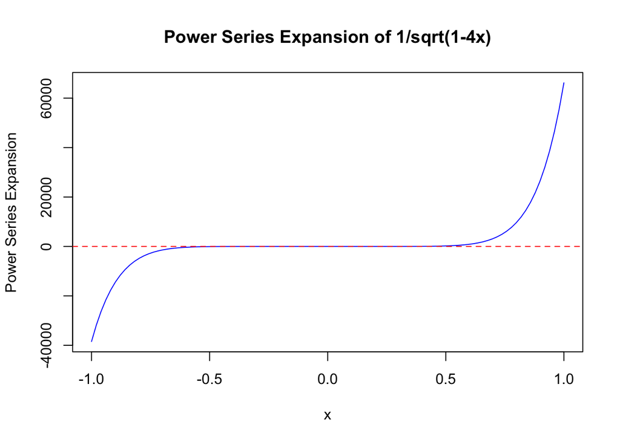

```r
# Define the function to calculate the power series
power_series <- function(x, n_terms) {
  series <- vector(mode = "numeric", length = n_terms)
  for (m in 0:(n_terms - 1)) {
    series[m + 1] <- choose(2 * m, m) * x^m
  }
  return(series)
}

# Define the number of terms in the series
n_terms <- 10

# Define the range of x values
x_values <- seq(-1, 1, length.out = 100)

# Calculate the power series for each x value
power_series_values <- sapply(x_values, function(x) sum(power_series(x, n_terms)))
# Plot the power series expansion
plot(x_values, power_series_values, type = "l", col = "blue",
     xlab = "x", ylab = "Power Series Expansion",
     main = "Power Series Expansion of 1/sqrt(1-4x)")

# Add a horizontal line at y = 0 for reference
abline(h = 0, lty = 2, col = "red")
```